# Trayendo IGN shapes to R

Pedro J. Pérez

04 febrero, 2018

## Intro y descarga del IGN

En los anteriores post me dedique a hacer mapas de los municipios españoles, así que me he decidido a actualizar mi fichero de *shapes*. Para ello toca ir a la web del [Instituto Geográfico Nacional](http://www.ign.es/web/ign/portal), concretamente al [centro de descargas](http://centrodedescargas.cnig.es/CentroDescargas/index.jsp). Una vez en el centro de descargas, hemos de ir a `Información geográfica de referencia` y luego a `Lineas límite municipales`. Trabajaré con los ficheros de “recintos”. Veamoslo:

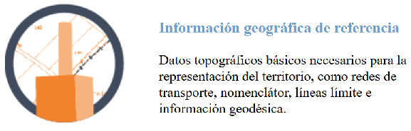

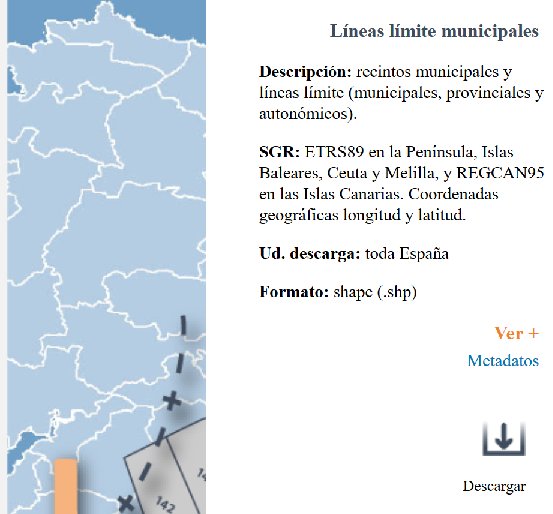

Al pinchar en `Descargar`, ee descarga un fichero zip. Yo lo descargué el **27 de enero de 2018**. Al descomprimirlo aparecen muchas carpetas: lineas y recintos para municipios, provincias y CC. AA.; además Canarias va aparte. Veámoslo:

[figure not shown]

## Lindes de CC.AA.

Trabajaré con los ficheros de “recintos”. Primero los recintos de las CC.AA. En España hay dieciséis comunidades autónomas y una comunidad foral (Navarra), además de Ceuta y Melilla, cuyos estatutos de autonomía les otorgan el rango de ciudades autónomas; así que a partir de ahora diremos que hay 19 CC.AA.

Cargo los datos con el paquete [sf](https://cran.r-project.org/web/packages/sf/index.html).

```r
library(tidyverse)
library(sf)
library(here)
aa <- paste0(here(), "./data_IGN/lineas_limite/recintos_autonomicas_inspire_peninbal_etrs89/recintos_autonomicas_inspire_peninbal_etrs89.shp")
ccaa_sf <- st_read(aa) #- 18 registros en Peninsula
aa <- paste0(here(), "./data_IGN/lineas_limite/recintos_autonomicas_inspire_canarias_wgs84/recintos_autonomicas_inspire_canarias_wgs84.shp")
ccaa_can_sf <- st_read(aa)  #- 1 registo en Canarias
```

Como ya dije los polígonos/shapes de Canarias van en fichero aparte y además resulta que están en [coordinate reference system](https://en.wikipedia.org/wiki/Spatial_reference_system) (CRS) diferentes. La península está en `epsg (SRID): 4258` mientras que Canarias está en `epsg (SRID): 4326`; así que antes de fusionar los dos ficheros, transformaré el de Canarias con `sf::st_transform()`:

```r
ccaa_can_sf<- st_transform(ccaa_can_sf, 4258) #- convierto de epsg(SRID):4326   a  epsg(SRID): 4258
```

Bien, sólo queda unir los dos conjuntos de shapes, lo haré con `rbind(..., deparse.level = 1)`

```r
#- para unirlos hay q usar rbind(..., deparse.level = 1)
ccaa_todas <- rbind(ccaa_sf, ccaa_can_sf, deparse.level = 1) #- 19 registros
```

Bueno, ya tengo en un único objeto (`ccaa_todas`) los shapes de las 19 CC.AA en el mismo CRS, sólo quedaría grabarlo en formato .rds; pero antes quiero añadirle los códigos INE para las CC.AA. Para ello, primero he de sacar el código de la CC.AA de la variable NATCODE:

```r
ccaa_todas <- ccaa_todas %>% mutate(INECodCCAA = str_extract(NATCODE, "^(....)"))   #- extraigo los 4 primeros caracteres de NATCODE
ccaa_todas <- ccaa_todas %>% mutate(INECodCCAA = str_extract(INECodCCAA, "(..)$"))   #- extraigo los 2 ultimos caracteres de INECodCCAA
```

Cargo los códigos del INE para las CC.AA y fusiono con los shapes:

```r
# devtools::install_github("perezp44/pjppkgRdata01")  #- personal pkg
library(pjppkgRdata01) #- personal pkg
INE_prov <-  cod_provincias
INE_prov <- INE_prov %>% select(CODAUTO, CCAA) %>% distinct()
INE_prov <- INE_prov %>% rename(INECodCCAA = CODAUTO)
INE_prov <- INE_prov %>% rename(NombreCCAA = CCAA)
IGN_CCAA_17 <- left_join(ccaa_todas, INE_prov) %>% select(INECodCCAA, NATCODE, NAMEUNIT, NombreCCAA, everything())
IGN_CCAA_17s <- IGN_CCAA_17 %>% select(INECodCCAA, NATCODE, NombreCCAA, geometry)
```

He creado dos objetos que guardaré después en el package que voy a crear: `IGN_CCAA_17` con 19 filas (una por C.A) y 11 columnas (está toda la información de los ficheros del IGN) y `IGN_CCAA_17s` (s significa “short”) donde solo dejo 4 columnas (INECodCCAA, NATCODE, NombreCCAA, geometry).

Para ver si lo he hecho ok, hagamos un gráfico

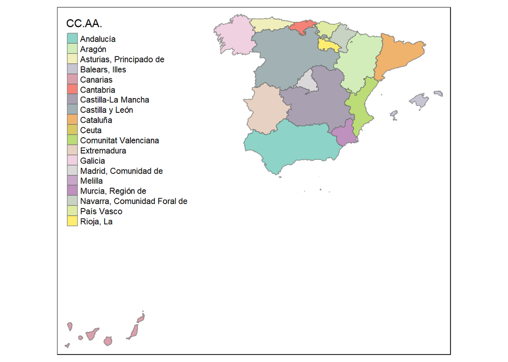

```r
library(tmap)
aa <- IGN_CCAA_17s %>%  select(NombreCCAA)
grafico <- tm_shape(aa, alpha = 0.3) +
  tm_fill(col = "NombreCCAA",  title = "CC.AA.") +
  tm_polygons(border.alpha = 0.6) +
  tm_layout(legend.position = c("left", "top"))
grafico
```

## Lindes provinciales

Bien, ahora toca arreglar los ficheros con los polígonos de lindes provinciales.

Cargamos los datos, saldrán 50 filas en el fichero de polígonos peninsulares y 2 en Canarias:

```r
aa <- paste0(here(), "./data_IGN/lineas_limite/recintos_provinciales_inspire_peninbal_etrs89/recintos_provinciales_inspire_peninbal_etrs89.shp")
prov_sf <- st_read(aa) #- 50 registros en Peninsula
aa <- paste0(here(), "./data_IGN/lineas_limite/recintos_provinciales_inspire_canarias_wgs84/recintos_provinciales_inspire_canarias_wgs84.shp")
prov_can_sf <- st_read(aa)  #- 2 registos en Canarias
```

Transformamos el CRS de canarias y unimos península y Canarias:

```r
prov_can_sf<- st_transform(prov_can_sf, 4258) #- convierto de epsg(SRID):4326   a  epsg(SRID): 4258
#- para unirlos hay q usar rbind(..., deparse.level = 1)
prov_todas <- rbind(prov_sf, prov_can_sf, deparse.level = 1) #- 52 registros
```

Extraigo códigos provinciales de la variable `NATCODE`:

```r
# NATCODE de la provincia de Teruel es  34024400000
prov_todas <- prov_todas %>% mutate(INECodProv = str_extract(NATCODE, "(.......)$"))   #- extraigo los 7 ultimos caracteres de NATCODE
prov_todas <- prov_todas %>% mutate(INECodProv = str_extract(INECodProv, "^(..)"))   #- extraigo los 2 primeros caracteres de INECodProv
```

Fusiono con códigos provinciales del INE:

```r
INE_prov <-  cod_provincias
INE_prov <- INE_prov %>% rename(INECodProv = CPRO)
INE_prov <- INE_prov %>% rename(NombreProv = PROVINCIA)
INE_prov <- INE_prov %>% rename(INECodCCAA = CODAUTO)
INE_prov <- INE_prov %>% rename(NombreCCAA = CCAA)
IGN_prov_17 <- left_join(prov_todas, INE_prov) %>% select(INECodProv, NATCODE, NAMEUNIT, NombreProv, NombreCCAA, everything())
IGN_prov_17s <- IGN_prov_17 %>% select(INECodProv, NATCODE, NombreProv, INECodCCAA, NombreCCAA, geometry)
```

Un gráfico con los lindes provinciales:

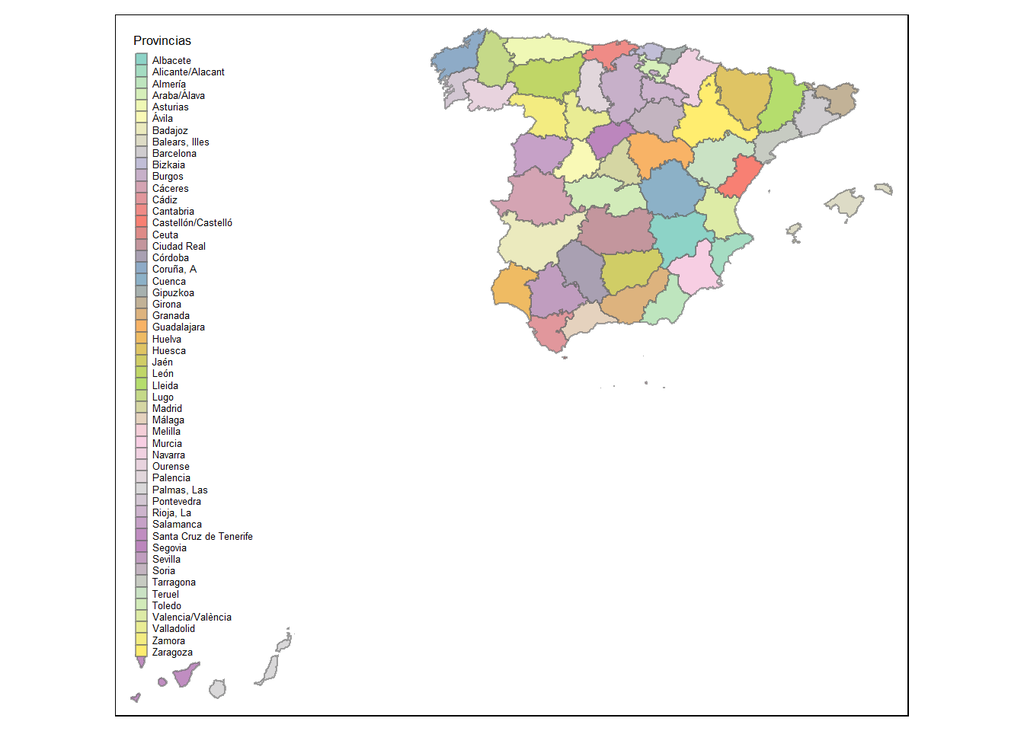

```r
library(tmap)
aa <- IGN_prov_17s %>%  select(NombreProv)
grafico <- tm_shape(aa, alpha = 0.3) +
  tm_fill(col = "NombreProv",  title = "Provincias") +
  tm_polygons(border.alpha = 0.6) +
  tm_layout(legend.position = c("left", "top"))
grafico
```

## Lindes municipales

Toca arreglar los ficheros con los polígonos de lindes municipales

Cargamos los datos, saldrán 8117 filas en el fichero de polígonos peninsulares y 94 en Canarias:

```r
aa <- paste0(here(), "./data_IGN/lineas_limite/recintos_municipales_inspire_peninbal_etrs89/recintos_municipales_inspire_peninbal_etrs89.shp")
mun_sf <- st_read(aa) #- 50 registros en Peninsula
aa <- paste0(here(), "./data_IGN/lineas_limite/recintos_municipales_inspire_canarias_wgs84/recintos_municipales_inspire_canarias_wgs84.shp")
mun_can_sf <- st_read(aa)  #- 2 registos en Canarias
```

Transformamos el CRS de canarias y unimos península y Canarias.

```r
mun_can_sf<- st_transform(mun_can_sf, 4258) #- convierto de epsg(SRID):4326   a  epsg(SRID): 4258
#- para unirlos hay q usar rbind(..., deparse.level = 1)
mun_todas <- rbind(mun_sf, mun_can_sf, deparse.level = 1) #- 8211 registros
```

Salen 8211 filas. Demasiados!!no hay tantos municipios en Spain!! Lo sé porque hace poco lo he mirado en el INE: en el último fichero que hay en el INE, **a 1 de enero de 2017 habían en España 8124 municipios**. ¿Por qué hay tantos shapes/polígonos/geometrías en el ING? No soy un experto, pero … cerca de mi despacho tengo uno que sí lo es y mirando uno de sus libros [aquí](https://www.fbbva.es/publicaciones/cambios-en-la-estructura-y-localizacion-de-la-poblacion-una-vision-de-largo-plazo-1842-2011/) se puede leer (en la página 311):

> La unidad terrotorial básica … es el municipio; sin embargo, se incluyen 84 dominios … que se administran por dos o más ayuntamientos, son los denominados condominios o territorios mancomunados. Tienen un caracter marcadamente historico …. y se concentran en las provincias de Burgos y Navarra.

En el libro se dice que hay 84 condominios, pero actualmente sólo hay 81. Se pueden identificar a través de la variable `NATCODE`. El NATCODE de mi pueblo es 34024444177; los últimos 5 dígitos conforman el código INE para mi pueblo: 44177, cuyos 2 primeros dígitos son el código provincial del INE. Bien, pues los territorios mancomunados tienen un código provincial en NATCODE de 53. Podríamos verlos con:

```r
# NATCODE de Pancrudo es 34024444177 filter(NATCODE == 34024444177)
# INECodMuni de Pancrudo es 44177  (o sea, unirlos x los 5 ultimos codigos)
mun_todas <- mun_todas %>% mutate(INECodMuni = str_extract(NATCODE, "(.....)$"))   #- extraigo los 5 ultimos caracteres de NATCODE
condominios <- mun_todas %>% filter(str_detect(INECodMuni, "^53"))  #- 81 shapes q empiezan x 53
no_condominios <- mun_todas %>% filter(!str_detect(INECodMuni, "^53"))  #- 8130 shapes q NO empiezan x 53 (sobran 6 q tienen q ver con los 6 municipios de la Gomera q tienen 2 rows)
```

Vamos a ver donde están los territorios mancomunados o condominios:

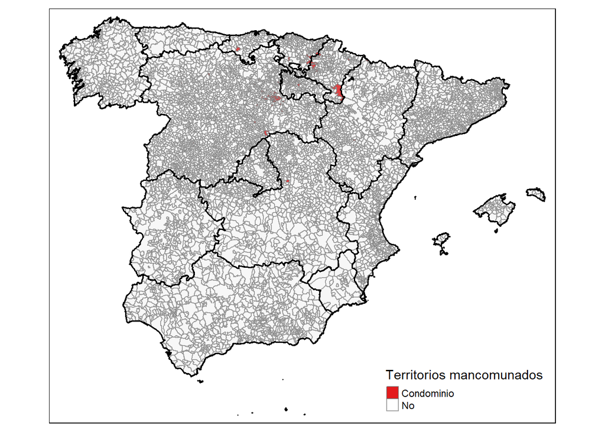

```r
virpalette <- c("#E41A1C", "white")
mun_xx <- mun_todas %>% mutate(Si_condo = ifelse(str_detect(INECodMuni, "^53"), "Condominio", "No"))
mun_xxx <- mun_xx %>% filter(!(str_detect(INECodMuni, "(^38)|(^35)")))  #- quito Canarias
ccaa_todas_xxx <- ccaa_todas %>% filter(!(str_detect(INECodCCAA, "^05")))  #- quito Canarias
map_condominios <- tm_shape(mun_xxx, alpha = 0.3) +
  tm_fill(col = "Si_condo", palette = virpalette, title = "Territorios mancomunados") +
  tm_polygons(border.alpha = 0.6) +
  tm_layout(legend.position = c("right", "bottom"))
map_condominios <- map_condominios + tm_shape(ccaa_todas_xxx, alpha = 0.2) + tm_polygons(lwd = 1.8, border.col = "black", alpha = 0.2)
map_condominios
```

No se ven muy bien, pero sí, están concentrados en las provincias de Burgos y Navarra. El condominio más grande son las [Bardenas Reales](https://es.wikipedia.org/wiki/Bardenas_Reales) en Navarra. Según la Wikipedia:

> El territorio de las Bardenas no pertenece a ningún municipio, con excepción de El Vedado de Eguaras que pertenece al municipio de Valtierra. El resto fue propiedad de la corona, de ahí el apelativo de Reales y en la actualidad es de dominio público siendo propiedad del gobierno de Navarra.

Los 81 condominios no los voy a quitar, como se pueden filtrar fácilmente los dejaré; PERO es que hay un segundo problema: si quitamos los 81 condominios nos quedarían 8.130 filas/polígonos geometrías, cuando sólo hay 8124 municipios, sobran 6 filas!!!

Después de tirarme de los pelos, descubrí que las seis filas “sobrantes” se debían a que habían seis municipios que tenían dos filas; concretamente esto ocurría en los 6 municipios que tiene la isla de La Gomera.

Mirando un poco más vi que cada uno de los 6 municipios de la Gomera tenía una row para el territorio del municipio en la isla de la Gomera y otro para una serie de “islitas” fuera de la isla de La Gomera; así que tenía varias posibilidades:

- fusionar esas dos shapes (para cada uno de los 6 municipios)
- eliminar las 6 rows con las islitas de La Gomera,
- cambiarles el código provincial y dejarlas en el fichero.

Al final decidí cambiar el código provincial (de las 6 rows con las islitas de La Gomera) para poder filtralas facilmente pero tenerlas en el fichero per si de cas. Lo hago con el chunk de abajo:

```r
#- identifiqué las rows donde estaban las islitas alrededor de La Gomera
islitas_Gomera <- c(8156L, 8158L, 8177L, 8193L, 8207L, 8209L) #- están son las 6 rows que voy a poner q su 38 de INECodMuni empiece pase a ser 66
mun_todas <- mun_todas %>% mutate(INECodMuni = str_extract(NATCODE, "(.....)$"))   #- extraigo los 5 ultimos caracteres de NATCODE
for (i in islitas_Gomera) {
  mun_todas$INECodMuni[i]  <- str_replace(mun_todas$INECodMuni[i] ,"38", "66")
}
```

Fusionar con el fichero de códigos INE:

```r
INE_mun <-  cod_muni_pjp_17   #- 8124 municipios (1-enero-2017)
IGN_mun_17 <- left_join(mun_todas, INE_mun) %>% select(INECodMuni, NATCODE, NAMEUNIT, NombreMuni, NombreProv, NombreCCAA, everything())
IGN_mun_17s <- IGN_mun_17 %>% select(INECodMuni, NATCODE, INECodProv, INECodCCAA, NombreProv, NombreCCAA, geometry)
```

Un gráfico con los lindes municipales:

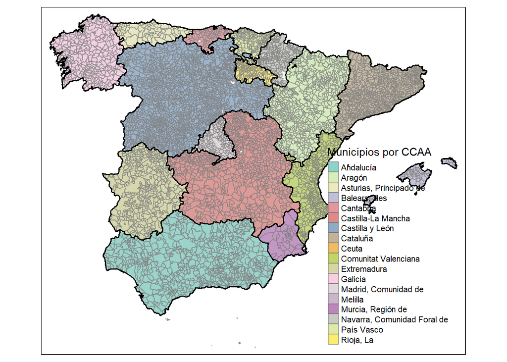

```r
library(tmap)
aa <- IGN_mun_17s %>%  select(NombreCCAA) %>% filter(NombreCCAA != "Canarias")
grafico <- tm_shape(aa, alpha = 0.3) +
  tm_fill(col = "NombreCCAA",  title = "Municipios por CCAA") +
  tm_polygons(border.alpha = 0.6) +
  tm_layout(legend.position = c("right", "bottom"))
quitar <- c("Canarias", "Ceuta", "Melilla")
bb <- IGN_CCAA_17s %>%  select(NombreCCAA) %>% filter(!(NombreCCAA %in% quitar))
grafico <- grafico + tm_shape(bb, alpha = 0.2) + tm_polygons(lwd = 1.8, border.col = "black", alpha = 0.2)

grafico
```

Bien, pues ya está. Me queda pasar los datos de lindes (municipales, provinciales y CCAA) a un package para así poderlos usar fácilmente. Yo ya sepo hacer packages; de hecho hice una charla en 2016 en las [VIII Jornadas de usuarios de R](http://r-es.org/8jornadasR/) . Uno de los tutoriales lo puedes ver [aquí](https://perezp44.github.io/pkg4albacete/). **PERO**, está vez quiero hacer el package con todo; es decir, teniendo cuidado con la documentación, incluyendo una vignette que sea útil, y creando una página web con `pkgdown`, incluso estoy pensando en ponerle badges y un hexsticker … Ya vorem!! En el próximo post se verá.